# WEEK 9: LINEAR REGRESSION & SIMULATING DISTRIBUTIONS

## Monday, March 6th

Today we will…

- Questions from Lab/Challenge 8
- Final Project Part 2 – Linear Regression
- Mini lecture on text material
  - Review of Simple Linear Regression
  - Conditions of Linear Regression
- PA 9.1: Mystery Animal
- Lab 9: Baby Names

## NC Births Data

The `ncbirths` data set is a random sample of 1,000 cases taken from a larger data set collected in North Carolina in 2004.

Each case describes the birth of a single child born in North Carolina, along with various characteristics of the child (e.g. birth weight, length of gestation, etc.), the child’s mother (e.g. age, weight gained during pregnancy, smoking habits, etc.) and the child’s father (e.g. age).

```r
library(openintro)
data(ncbirths)
head(ncbirths) |>
  knitr::kable() |>
  kableExtra::scroll_box(height = "200px")
```

| fage | mage | mature | weeks | premie | visits | marital | gained | weight | lowbirthweight | gender | habit | whitemom |
| --- | --- | --- | --- | --- | --- | --- | --- | --- | --- | --- | --- | --- |
| NA | 13 | younger mom | 39 | full term | 10 | not married | 38 | 7.63 | not low | male | nonsmoker | not white |
| NA | 14 | younger mom | 42 | full term | 15 | not married | 20 | 7.88 | not low | male | nonsmoker | not white |
| 19 | 15 | younger mom | 37 | full term | 11 | not married | 38 | 6.63 | not low | female | nonsmoker | white |
| 21 | 15 | younger mom | 41 | full term | 6 | not married | 34 | 8.00 | not low | male | nonsmoker | white |
| NA | 15 | younger mom | 39 | full term | 9 | not married | 27 | 6.38 | not low | female | nonsmoker | not white |
| NA | 15 | younger mom | 38 | full term | 19 | not married | 22 | 5.38 | low | male | nonsmoker | not white |

## Relationships Between Variables

In a statistical model, we generally have one variable that is the output and one or more variables that are the inputs.

- Response variable
  - a.k.a. $y$, dependent
  - The quantity you want to understand
- Explanatory variable
  - a.k.a. $x$, independent, explanatory, predictor
  - Something you think might be related to the response

## Visualizing the Relationship

The scatterplot has been called the most “generally useful invention in the history of statistical graphics.”

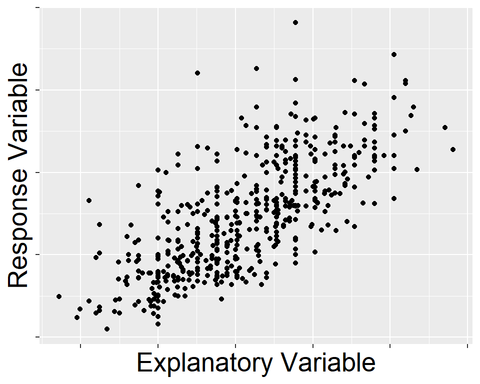

**Characterizing relationships**

- Form – linear, quadratic, non-linear?
- Direction – positive, negative?
- Strength – how much scatter/noise?
- Unusual observations – do points not fit the overall pattern?

## Your turn!

How would your characterize this relationship?

- shape
- direction
- strength
- outliers

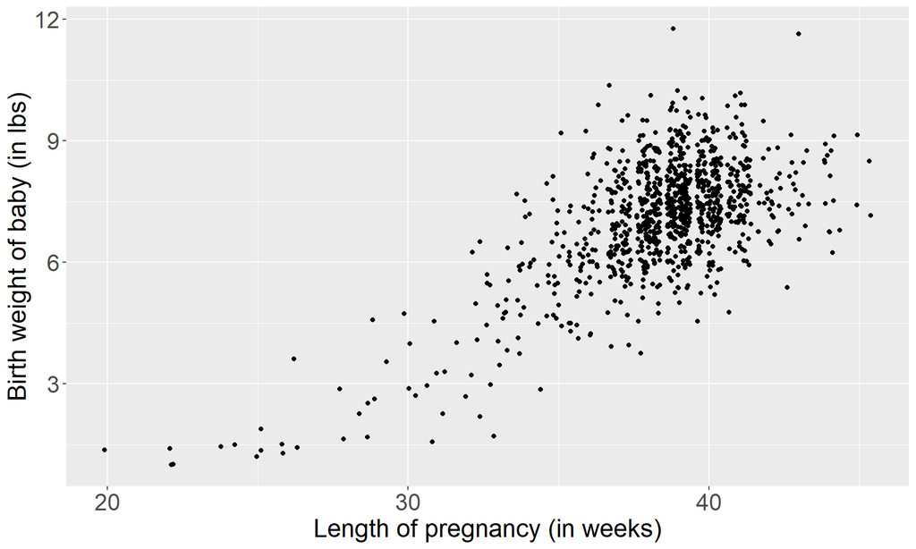

## Simple Linear Regression (SLR)

Assume the relationship between $x$ and $y$ takes the form of a linear function.

$$response = intercept + slope \cdot explanatory + noise$$

**Population Regression Model**

$Y = \beta_0 + \beta_1 \cdot X + \epsilon_i$

$\epsilon \sim N(0, \sigma)$

**Fitted Regression Model (*Sample*)**

$\hat{y} = \hat{\beta}_0 + \hat{\beta}_1 \cdot x$

## Fitting an SLR Model

- `geom_smooth(method = "lm")`
- `lm`
- Coefficients
- Residuals

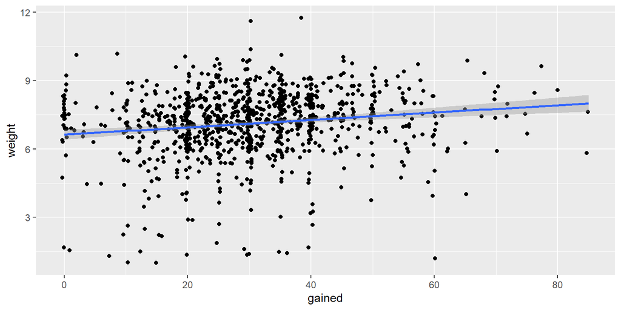

```r
ncbirths |>
ggplot(aes(x = gained,
           y = weight)
       ) +
  geom_jitter() +
  geom_smooth(method = "lm")
```

```r
ncbirth_lm <- lm(weight ~ gained,
                 data = ncbirths
                 )
```

```r
library(broom)
tidy(ncbirth_lm)
```

```
# A tibble: 2 × 5
  term        estimate std.error statistic    p.value
  <chr>          <dbl>     <dbl>     <dbl>      <dbl>
1 (Intercept)   6.63     0.111       59.6  0
2 gained        0.0161   0.00332      4.86 0.00000135
```

- Intercept: Expected **mean** value for $y$, when $x$ is 0
- Slope: Expected change in the **mean** of $y$, when $x$ is increased by 1 unit

Difference between the observed (point) and the expected (line).

```r
ncbirth_lm$residuals |>
  head(3)
```

```
         1          2          3
 0.3866279  0.9271567 -0.6133721
```

```r
resid(ncbirth_lm) |>
  head(3)
```

```
         1          2          3
 0.3866279  0.9271567 -0.6133721
```

```r
library(broom)
augment(ncbirth_lm) |>
  head(3)
```

```
# A tibble: 3 × 9
  .rownames weight gained .fitted .resid    .hat .sigma   .cooksd .std.resid
  <chr>      <dbl>  <int>   <dbl>  <dbl>   <dbl>  <dbl>     <dbl>      <dbl>
1 1           7.63     38    7.24  0.387 0.00133   1.47 0.0000458      0.262
2 2           7.88     20    6.95  0.927 0.00157   1.47 0.000311       0.630
3 3           6.63     38    7.24 -0.613 0.00133   1.47 0.000115      -0.416
```